## Introduction

**Scover** takes as input a set of sequences and a set of numeric values associated with each sequence (typically represented as a matrix). The sequences can be any type of nucleotides, e.g.

- Promoter sequences
- Peak sequences
- UTRs

The values represent transcriptional activity, accessibility, or some other property associated with each sequence. It is assumed that each cell has a value and that values can be averaged across a randomly selected pool of cells from the same cell type. **scover** utilizes the cell type annotation to pool cells from the same group by sampling without replacement.

In this workflow, I am starting from a `SingleCellExperiment` object containing scRNA-seq data (see [this page](https://bioconductor.org/packages/release/bioc/vignettes/SingleCellExperiment/inst/doc/intro.html) for additional information) - if you start from a counts matrix, follow the [instructions](https://bioconductor.org/packages/release/bioc/vignettes/SingleCellExperiment/inst/doc/intro.html) to construct a `SingleCellExperiment` object. If you are starting from a `Seurat` object, [their website](https://satijalab.org/seurat/v3.0/conversion_vignette.html) contains useful information on how to convert this to a `SingleCellExperiment` object.

This workflow is the more detailed data generation file - if you are just interested in getting started quickly, there is a [script](https://htmlpreview.github.io/?https://github.com/jacobhepkema/scover/blob/master/guides/how_to_prepare_scover_dataset_using_create_dataset.html) for this. You can then start from a `SingleCellExperiment` object with the cell type annotation stored in `colData(sce)$cell_type1` (where `sce` is the `SingleCellExperiment` object) . However, it is always a good idea to use your judgement to decide if the steps make sense - having a ‘human in the loop’ for both the preprocessing and the analysis of the model output will often help.

Note that there is a different guide for [preparing scATAC-seq data](https://scover.readthedocs.io/en/latest/how_to_prepare_scover_input_using_scATAC_seq.html).

## Loading the required packages and helper functions

I am using the following packages during this part of the workflow:

```r
suppressMessages(library(AnnotationHub))
suppressMessages(library(assertr))
suppressMessages(library(Biostrings))
suppressMessages(library(GenomicRanges))
suppressMessages(library(Matrix))
suppressMessages(library(SingleCellExperiment))
suppressMessages(library(scater))
suppressMessages(library(stringr))

options(stringsAsFactors = F)
```

See the end of this page for the full `sessionInfo()`.

In addition, I get my helper functions (e.g. `pool_cells()`) from this file:

```r
source("scover_helper_functions.R")
```

**Important**: All of the required R scripts and fasta files are included in the `data_generation` folder of this repository.

## Creating a dataset from a scRNA-seq dataset

Load your `SingleCellExperiment` object. In this case I am using the bone marrow dataset from [Tabula Muris](https://tabula-muris.ds.czbiohub.org/):

```r
sce <- readRDS(paste0(tm_dir, "TMFACS_Marrow.rds"))
```

Make sure that the cell type information is stored in the `$cell_type1` column of `colData(sce)`. You can check this using:

```r
table(sce$cell_type1)
```

```
##
##                   astrocyte of the cerebral cortex
##                                                  0
##                                             B cell
##                                               1848
##                                         basal cell
##                                                  0
##                            basal cell of epidermis
##                                                  0
##                           basal cell of urothelium
##                                                  0
##                                Bergmann glial cell
##                                                  0
##                                       bladder cell
##                                                  0
##                                     brain pericyte
##                                                  0
## Brush cell of epithelium proper of large intestine
##                                                  0
##                                cardiac muscle cell
##                                                  0
##                                      ciliated cell
##                                                  0
##                                         Clara cell
##                                                  0
##                                     dendritic cell
##                                                  0
##                                   endocardial cell
##                                                  0
##                                   endothelial cell
##                                                  0
##               endothelial cell of hepatic sinusoid
##                                                  0
##        enterocyte of epithelium of large intestine
##                                                  0
##                               enteroendocrine cell
##                                                  0
##                               epicardial adipocyte
##                                                  0
##                                     epidermal cell
```

[output cut: 84 more lines]

```
##                                                  0
##                             stem cell of epidermis
##                                                  0
##                                       stromal cell
##                                                  0
##                                             T cell
##                                                142
##                             type B pancreatic cell
##                                                  0
##                                  type I pneumocyte
##                                                  0
##                                 type II pneumocyte
##                                                  0
##                                            unknown
##                                                  0
```

Also make sure that the cell type information does not contain any `NA`s.

```r
sce <- sce[,!is.na(sce$cell_type1)]
```

In addition, it is often a good idea to exclude cells that have an “unknown” cell type.

## Determining optimal pool size

Pooling cells together for **scover** is a trade off between getting rid of undesirable zeroes in your count matrix and retaining variability between cells and cell types. For the datasets that I have analyzed, the method works reasonably well when the sparsity is between 20% and 50% - aiming for a sparsity below 50% is usually a good idea. However, I recommend that you try a couple of different settings since the performance can depend on your dataset.

Also, it is sometimes impossible to reduce the sparsity to the desired level - in that case, I recommend that you try a couple of different pool sizes to see what works best.

One way to check how sparsity goes down for different pool sizes is through: (the `pool_cells()` and `get_sce_sparsity()` functions are from `scover_helper_functions.R`)

```r
sparsities <- c()
for(pool_size in c(12,30,50,100,200)){
  sparsities <- c(sparsities, get_sce_sparsity(pool_cells(sce, pool_size=pool_size)))
}
```

```
## Pooling cells per cell type with pool_size 12
##
## Dropout ratio: 0.602
## Cell number: 404
## Done
##
## Pooling cells per cell type with pool_size 30
##
## Dropout ratio: 0.52
## Cell number: 158
## Done
##
## Pooling cells per cell type with pool_size 50
##
## Dropout ratio: 0.479
## Cell number: 92
## Done
##
## Pooling cells per cell type with pool_size 100
##
## Dropout ratio: 0.425
## Cell number: 44
## Done
##
## Pooling cells per cell type with pool_size 200
## Not including cell type Fraction A pre-pro B cell
## Not including cell type natural killer cell
## Not including cell type T cell
##
## Dropout ratio: 0.37
## Cell number: 19
## Done
```

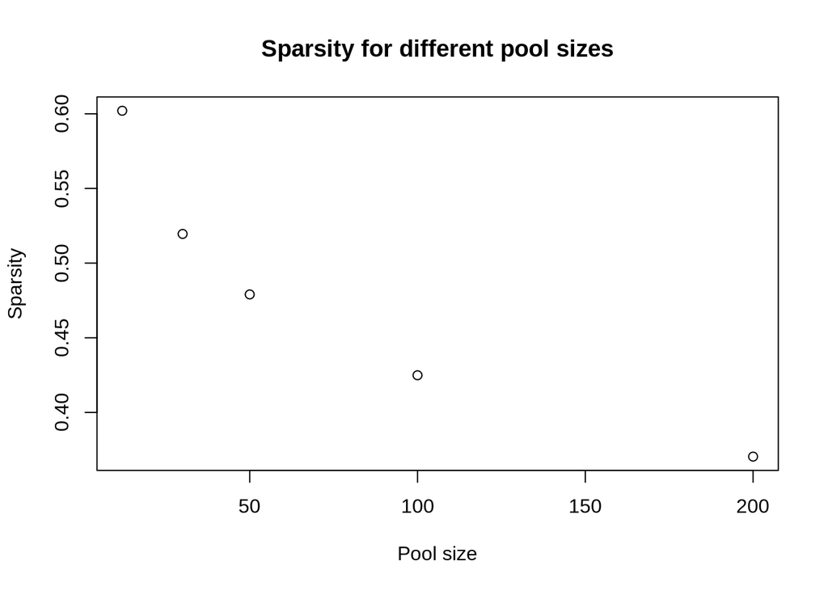

```r
plot(x=c(12,30,50,100,200), y=sparsities,
     main="Sparsity for different pool sizes",
     xlab="Pool size", ylab="Sparsity")
```

In this case, I will use `pool_size = 50`. I use the `pool_cells_follow_cells()` function to keep track of which cells end up in which pools.

```r
pool_output <- pool_cells_follow_cells(sce, pool_size=50, keep_smaller_pools = F)
```

```
## Pooling cells per cell type with pool_size 50
##
## Dropout ratio: 0.479
## Cell number: 92
## Done
```

```r
pooled_sce <- pool_output[[1]]
pooled_sce_cells_in_pools <- pool_output[[2]]
```

## Extracting sequences

For this particular dataset, I know that `mm10` was used, so I will obtain the relevant sequences from the mm10 genome with 500 bp upstream and 500 bp downstream of the TSS for each gene. This file is included in the `data_generation` folder of this repository.

```r
seqs <- Biostrings::readDNAStringSet("mm10_500up500down_promoters.fa.gz")

# Get genes and to-be-predicted data (log-normalized counts of sce)
genelist <- rownames(pooled_sce)
data <- logcounts(pooled_sce)

# Figure out which genes are not included in the sequences list:
not_in_fasta <- genelist[!(genelist %in% names(seqs))]

length(not_in_fasta)
```

```
## [1] 2403
```

If this last number (`length(not_in_fasta)`) is very high, it is likely that you are using the wrong version of the genome. I have included other fasta files for these sequences in this repository; e.g. `hg38_500up500down_promoters.fa.gz`. It is also possible to extract your own sequences using `AnnotationHub` - I’ve created a guide at this page.

Filter out cells/genes with too high dropout:

```r
genelist <- genelist[genelist %in% names(seqs)]

cell_dropouts <- colSums(data == 0) / dim(data)[1]
too_high_cell_dropouts <- cell_dropouts > 0.98
cat(sum(too_high_cell_dropouts))
```

```
## 0
```

```r
data <- data[,!too_high_cell_dropouts]
pooled_sce <- pooled_sce[,!too_high_cell_dropouts]

gene_dropouts <- rowSums(data == 0) / dim(data)[2]
too_high_gene_dropouts <- genelist[gene_dropouts[genelist] > 0.98]
cat(length(too_high_gene_dropouts))
```

```
## 3916
```

```r
genelist <- genelist[!(gene_dropouts[genelist] > 0.98)]

cat("Genelist of", length(genelist), "genes\n")
```

```
## Genelist of 17022 genes
```

```r
cat("Cell/pool number:", ncol(data),"\n")
```

```
## Cell/pool number: 92
```

Extract the sequences and the values to be used for the prediction task:

```r
seqs <- base::tolower(as.character(seqs[genelist]))
ind <- assertr::col_concat(data[genelist,], sep=",")
```

Now all that is left is to write three tables:

1. The table containing the sequences and the associated values
2. The table containing annotations for the different cell pools
3. The table containing information about which cell ended up in which pool

```r
dataset <- data.frame(gene=genelist,
                      sequence=seqs,
                      ind=ind)

# File 1
write.table(dataset, gzfile("TMFACS_Marrow_pool50.tsv.gz"),
            sep="\t", row.names = F, col.names = T, quote = F)

# File 2
write.table(colData(pooled_sce), "TMFACS_Marrow_pool50_colData.tsv",
            sep="\t", row.names = T, col.names = T, quote = F)

# File 3
write.table(pooled_sce_cells_in_pools, "TMFACS_Marrow_pool50_cells_in_pools.tsv",
            sep="\t", row.names = T, col.names = T, quote = F)
```

You want to pass file 1) to the `--data` argument of scover, and argument 2) to `--celldata` of scover. The third file ensures that it is possible to reproduce the pooling. For more information on how to run **scover**, see the main readme file in the root of this repository.